# AquaMaps ingest

Ben Best

2018-07-19

## Initialize

- [AquaMaps Environmental Dataset: Half-Degree Cells Authority File (HCAF)](https://www.aquamaps.org/main/envt_data.php)

```r
library(tidyverse)
library(glue)
library(fs)
library(raster)
library(leaflet)

# dir & csv's
#dir_dat   <- "/Users/bbest/Desktop/aquamaps_ver0816c"
dir_dat   <- "/Volumes/Best HD/mbon_data_big/aquamaps"
spp_csv   <- file.path(dir_dat, "speciesoccursum_ver0816c.csv")
obs_csv   <- file.path(dir_dat, "occurrencecells_ver0816c_head-100K-rows.csv")
#cells_csv <- file.path(dir_dat, "hcaf_species_native_ver0816c_head-100K-rows.csv")
cells_csv <- file.path(dir_dat, "hcaf_species_native_ver0816c.csv")
env_csv   <- file.path(dir_dat, "hcaf_v6.csv")
dir_spp   <- file.path(dir_dat, "species_rasters")

spp   <- read_csv(spp_csv) # head(occ)
#cells <- read_csv(cells_csv)
#obs   <- read_csv(obs_csv)

# AquaMaps raster specifications for 0.5 degree global raster
r_na <- raster(
  xmn = -180, xmx = 180, ymn = -90, ymx = 90,
  resolution=0.5, crs=leaflet:::epsg4326)
r_a <- area(r_na)

r_1 <- setValues(r_na, 1)

# writeRaster(r_a, path(dir_dat, "global_area.tif"))
# writeRaster(r_1, path(dir_dat, "global_1.tif"))

env <- read_delim(env_csv, delim = "\t")
# TODO: use env.OceanArea for r_a
```

```r
raster_trim <- function(r){
  # source: /Users/bbest/github/nrelutils/R/raster_utils.R

  # raster::trim() crazy slow compared to this
  r_m          <- is.na(raster::as.matrix(r))
  col_notna    <- which(colSums(r_m) != nrow(r))
  row_notna    <- which(rowSums(r_m) != ncol(r))
  extent_notna <- raster::extent(
    r,
    row_notna[1], row_notna[length(row_notna)],
    col_notna[1], col_notna[length(col_notna)])
  raster::crop(r, extent_notna)
}

sp_id_to_tif <- function(sp_id){
  # , cells=cells, r_na=r_na, dir_spp=dir_spp

  # get cells
  cells_sp <- cells %>%
    filter(SpeciesID == sp_id) %>%
    mutate(
      cell = cellFromXY(r_na, matrix(data = c(CenterLong, CenterLat), ncol=2)))

  # assign to raster
  r_sp <- r_na
  r_sp[cells_sp$cell] <- cells_sp$probability
  r_sp <- raster_trim(r_sp) # plot(r_sp)

  # write out
  r_sp_tif <- glue("{dir_spp}/{sp_id}.tif")
  writeRaster(r_sp, r_sp_tif, overwrite=T)
}
```

## Table (*.csv) to Map (*.tif) for All Species

```r
cells <- read_csv(cells_csv)

spp_ids <- distinct(cells, SpeciesID) %>% pull(SpeciesID)

# takes 8.8 hours, 472 MB
for (i in 1:length(spp_ids)){ # i = 1
  cat(sprintf("%04d of %d: %s -- %s\n", i, length(spp_ids), sp_id, Sys.time()))
  # https://www.aquamaps.org/preMap2.php?cache=1&SpecID=Fis-22812
  sp_id <- spp_ids[i]

  sp_id_to_tif(sp_id)
}

# estimate time to completion ----

# 0001 of 24904: Fis-22812 -- 2018-07-01 20:49:01
# 0349 of 24904: Fis-29786 -- 2018-07-01 20:56:19
# 1214 of 24904: Fis-30623 -- 2018-07-01 21:15:14
# 24904 of 24904: WBD-Eup-82 -- 2018-07-02 05:36:41
i_all <- 24904; t_beg <- as_datetime("2018-07-01 20:49:01")
i_now <- 1214; t_now <- as_datetime("2018-07-02 05:36:41")
difftime(t_now, t_beg, units="hours") / i_now * (i_all - i_now) + t_now

# calculate avg file size ----
dir_spp <- "/Volumes/Best HD/mbon_data_big/aquamaps/species_rasters"
file_info(dir_ls(dir_spp)) %>%
  summarize(
    size = mean(size)) %>%
  pull(size) * 24904 / 1000000
```

## Load into PostGIS DB

```bash
gdal2wktraster.py -r C:\Temp\TutData\SRTM\tif\*.tif -t srtm_tiled
      -s 4326 -k 60x60 -I > C:\Temp\TutData\SRTM\srtm.sql
```

## Range Normalized Cumulative Species Map

To demonstrate the methodology of “range normalization”, let’s compare a cumulative species map with and without range normalization for two species with very different ranges:

- **contracted**: [North Atlantic right whale (*Eubalaena glacialis*)](https://www.aquamaps.org/preMap2.php?cache=1&SpecID=ITS-Mam-180537)

[figure not shown]

- **expansive**: [blue whale (*Balaenoptera musculus*)](https://www.aquamaps.org/preMap2.php?cache=1&SpecID=ITS-Mam-180528)

[figure not shown]

For a given cell ($c$), we might simply take the sum of AquaMap’s Relative Environmental Suitability (RES; $e$; ranging in value [0, 1]) per species ($s$) across the number of species ($S$) to arrive at a cumulative species richness ($R$) that is weighted by the species suitability within the given cell:

$${R_c} = \sum_{s=1}^{S} e_{s,c}$$

This approach however gives equal weight for any given cell to a species with a contracted range as an expansive one. From a population perspective, this overrepresents the expansive range. To account for small areas with high degrees of unique endemism, we can “range normalize” by dividing the given relative environmental suitability for the species and cell ($e_{s,i}$) by the sum of the species relative environmental suitability ($E_s$) across all cells ($C$), i.e. the whole range, and further account for cell area ($a_c$) and IUCN extinction risk as a species weight ($w_s$):

$$E_s = \sum_{c=1}^{C} e_{s,c} * a_c \\
{RN\ R_c} = \sum_{s=1}^{S} \frac{ e_{s,c} * a_c * w_s }{ E_s }$$

- $a_c$: area of cell
- $c$: cell
- $e$: AquaMap’s Relative Environmental Suitability (RES; ranging in value [0, 1])
- $E_s$: total environmental suitability, per species
- $R_c$: species richness, per cell
- $RN R_c$: range normalized species richness, per cell
- $s$: species
- $S$: total number of species
- $w_s$: IUCN extinction risk weight of species

Note that the (IUCN extinction risk) weight ($w_s$) is not part of the range normalization denominator ($E_s$) so when summing species those with higher extinction risk are given more weight.

### Accounting for Area?

The equation above is problematic because it biases equatorial cells and downweights poleward cells.

$$E_s = \sum_{c=1}^{C} e_{s,c} * a_c \\
R_{s,c} = \frac{ e_{s,c} * a_c}{ E_s} \\
{RN\ R_c} = \sum_{s=1}^{S} R_{s,c} * e_{s,c} * w_s$$

Alternatively, we describe a range normalization factor per species ($N_s$) that can be applied to all cells ($C$) regardless of area relative to some minimum range size we define as 1.

$$E_s = \sum_{c=1}^{C} e_{s,c} * a_c \\
N_s = \frac{min\{E_1, ..., E_S\}}{E_s} \\
NR_c = \sum_{s=1}^{S} e_{s,c} * N_{s} * w_s$$

- $E_s$: sum of environmental suitability across range, ie all cells, per species $_s$
- $e_{s,c}$: AquaMap’s Relative Environmental Suitability (RES; ranging in value [0, 1]) per species $_s$ and cell $_c$
- $a_c$: area of cell $_c$
- $C$: all cells
- $N_s$: range normalization factor, per species $_s$
- $\{E_1, ..., E_S\}$: set of species environmental suitability sums $E_s$ across all species $_S$
- $NR_c$: range normalized species richness per cell $_c$, also weighted by extinction risk $w$
- $w_s$: IUCN extinction risk weight of species

Note that the (IUCN extinction risk) weight ($w_s$) is not part of the range normalization denominator ($E_s$) so when summing species those with higher extinction risk are given more weight.

```r
# species id's for right whale and blue whale
sid_blue  <- "ITS-Mam-180528"
sid_right <- "ITS-Mam-180537"

# IUCN extinction risk status
ext_blue  <- "EN"
ext_right <- "CR"

# extinction risk weights
# bumping up LC to 0.2 to give credit for presence and not expecting extinct 1.2
ext_wts <- c(LC=0.2, NT=0.4, VU=0.6, EN=0.8, CR=1, EX=1.2)
w_blue  <- ext_wts[ext_blue]
w_right <- ext_wts[ext_right]

get_am_raster <- function(sid, w=NULL, weight_area=T, range_normalize=T, attr_leaflet=T, extend_global=T){
  # Get AquaMaps raster
  # TODO: threshold param for binary output
  # sid: species id # sid <- sid_right
  # sid=sid_right; weight_area=T; range_normalize=T; attr_leaflet=T; extend_global=T; w=w_right

  # read tif
  tif <- glue("{dir_spp}/{sid}.tif")
  r <- raster(tif, crs=leaflet:::epsg4326)

  # set boundaries
  b <- extent(r)

  a = "attributes" # names(attributes(r)) # names(attributes(a))
  attr(a, "bounds") <- list(lng1 = b@xmin, lat1 = b@ymin, lng2 = b@xmax, lat2 = b@ymax)

  # extend to global for calculations
  r <- extend(r, r_na)

  attr(a, "cell_avg_e") = cellStats(r, "mean", na.rm=T)
  attr(a, "sum_e") <- cellStats(r, stat='sum', na.rm=T)

  if (weight_area){
    r <- r * r_a

    attr(a, "cell_avg_e_a") = cellStats(r, "mean", na.rm=T)
    attr(a, "sum_area_km2")   <- cellStats(mask(r_a, r), stat='sum', na.rm=T)
    attr(a, "sum_e_area_km2") <- cellStats(r, stat='sum', na.rm=T)
  }

  if (range_normalize){
    E_s <- ifelse(weight_area, attr(a, "sum_e_area_km2"), attr(a, "sum_e"))
    r <- r / E_s

    attr(a, "E_s") <- ifelse(weight_area, "sum_e_area_km2", "sum_e")
    attr(a, "cell_avg_e_a_Es") = cellStats(r, "mean", na.rm=T)
  }

  if (!is.null(w)){
    r <- r * w

    attr(a, "w") <- w
    attr(a, "cell_avg_w") = cellStats(r, "mean", na.rm=T)
  }

  attr(a, "cell_avg") = cellStats(r, "mean", na.rm=T)

  if (attr_leaflet){
    r_leaflet <- projectRasterForLeaflet(raster_trim(r), method="ngb")
    attr(a, "r_leaflet") <- r_leaflet
  }

  if (!extend_global)
    r <- raster_trim(r)

  # append attributes
  walk(names(attributes(a)), function(x){
    attr(r, x) <- attributes(a)[[x]]
    assign("r", r, pos = parent.frame(n=2), inherits = FALSE)})
  #names(attributes(a))
  #names(attributes(r))

  r
}

# rasters for species relative environmental suitability [0 - 1]
r_right <-  get_am_raster(sid_right, weight_area=F, range_normalize=F) # plot(r_right)
r_blue  <-  get_am_raster(sid_blue, weight_area=F, range_normalize=F)   # plot(r_blue)
r_right_w_a_r <-  get_am_raster(sid_right, w=w_right, weight_area=T, range_normalize=T) # plot(r_right)
r_blue_w_a_r  <-  get_am_raster(sid_blue, w=w_blue, weight_area=T, range_normalize=T)   # plot(r_blue)

# names(attributes(r_right))
# attr(r_blue, "cell_avg")
# attr(r_right, "cell_avg")
# attr(r_right, "sum_area_km2")

sum_am_rasters <- function(..., attr_leaflet=T){
#add_am_rasters <- function(..., spp_wts=NULL, spp_range_normalize=T, spp_all_normalize=T){
  # spp_range_normalize: for each species map, divide by sum of all pixels, before summing
  # spp_all_normalize: after summing all species maps, divide by max pixel value to get range [0,1]
  # spp_wts: species weights, to apply in same order as rasters. defaults to 1
  # TODO: add species richness factor, so more species -> stronger result
  # ...: rasters

  rasters <- list(...)
  s <- stack(rasters)

  # if (!is.null(spp_wts)){
  #   stopifnot(length(rasters)==length(spp_wts))
  #   for (i in 1:length(spp_wts))
  #     s[[i]] <- raster(s, layer=i) *  spp_wts[i]
  # } #else {
    #spp_wts = rep(1, length(rasters))
  #}

  # spp_wts <- ext_wts[c(ext_right, ext_blue)]

  # get weighted mean
  #r <- weighted.mean(s, spp_wts)

  # sum across all species rasters
  #r <- calc(s, function(x) )
  #r <- calc(s, fun = sum, na.rm = T)
  r <- sum(s, na.rm = T)
  #plot(raster(s, layer=1), col=rev(rainbow(255)))

  # mask
  m <- overlay(s, fun=function(x) ifelse(sum(!is.na(x)) > 0, 1, NA))
  r <- mask(r, m)

  # trim
  #r <-
  #summary(r); plot(r, col=rev(rainbow(255)))
  #summary(r0); plot(r0, col=rev(rainbow(255)))
  #summary(r0); plot(stack, r0)
  #r <- calc(s, fun = sum, na.rm = T)
  #summary(r0)

  # if (spp_all_normalize)
  #   r <- r / cellStats(r, stat='max', na.rm=T)

  # project for leaflet
  if (attr_leaflet)
    attr(r, "r_leaflet")  <- projectRasterForLeaflet(raster_trim(r), method="ngb")

  r
}

#r_sum   <- add_am_rasters(r_right, r_blue, spp_range_normalize=F, spp_all_normalize=F, spp_wts = NULL)
#r_nrsum <- add_am_rasters(r_right, r_blue, spp_range_normalize=T, spp_all_normalize=F, spp_wts = NULL)
r_sum   <- sum_am_rasters(r_right, r_blue) # plot(r_sum)
r_nrsum <- sum_am_rasters(r_right_w_a_r, r_blue_w_a_r)

#plot(r_sum)
#plot(r_nrsum)
#r_add3 <- add_am_rasters(r_right, r_blue, spp_range_normalize=T, spp_all_normalize=T, spp_wts = NULL)
#r_add4 <- add_am_rasters(r_right, r_blue, spp_range_normalize=T, spp_all_normalize=T,
#                         spp_wts = ext_wts[c(ext_right, ext_blue)])

# summary(r_sum)
# summary(r_nrsum)
# summary(r_add3)
# summary(r_add4)

fit_am_raster <- function(map, r){
  bounds <- attr(r, "bounds")
  with(bounds, fitBounds(map, lng1, lat1, lng2, lat2))
}

add_am_raster <- function(m, r, lyr_name, r_type="spp"){
  # r_type="spp" or "sum"
  # r <- r_right
  r <- attr(r, "r_leaflet")

  max_r <- cellStats(r, stat='max', na.rm=T)
  sum_r <- cellStats(r, stat='sum', na.rm=T)

  rng <- c(0, 1)
  if (r_type != "spp"){
    rng <- c(0, max_r)
  }

  pal <- colorNumeric(
    "inferno", rng, na.color = "transparent", reverse=T)

  lab_sci <- function(v, type="numeric"){
    #browser()
    if (r_type == "spp"){
      labs <- case_when(
        v == 0 ~ "0, 0",
        v == last(v) ~ as.character(glue(
          "{v}, {formatC(v/sum_r, format = 'e', digits = 1)}")),
        TRUE ~ "")
    } else {
      #if (lyr_name == "sum NR RES") browser()
      labs <- case_when(
        v == 0 ~ "0, 0",
        v == last(v) ~ as.character(glue(
          "{v}, 1")),
        TRUE ~ "")
    }
    labs
  }

  m %>%
    addRasterImage(
      r, colors = pal, opacity = 0.6, project=F,
      group=lyr_name) %>%
    addLegend(
      group = lyr_name, pal = pal,
      position = "bottomright",
      values = rng, labFormat = lab_sci,
      title = ifelse(
        r_type == "spp",
        glue("{lyr_name} (RES, E_s)<br>&nbsp;&nbsp;sum={format(sum_r, big.mark=',', digits=1, nsmall=1)}"),
        glue("{lyr_name} (max, 1)")))
}

map_am_layer <- function(lyr){

  m <- leaflet() %>%
    addProviderTiles(
      providers$Esri.OceanBasemap, options=providerTileOptions(opacity=0.6)) %>%
    add_am_raster(r_right, "right whale") %>%
    add_am_raster(r_blue, "blue whale") %>%
    add_am_raster(r_sum, "sum", r_type="sum") %>%
    add_am_raster(r_nrsum, "sum RN", r_type="sum") %>%
    addLayersControl(
      baseGroups = c("ESRI Ocean Basemap"),
      overlayGroups = c("right whale", "blue whale", "sum", "sum RN"),
      #overlayGroups = c("right whale", "blue whale", "sum"),
      options = layersControlOptions(collapsed = T)) %>%
    fit_am_raster(r_blue) %>%
    addMiniMap(position = "bottomleft", toggleDisplay = T, minimized = T) %>%
    hideGroup("blue whale") %>%
    hideGroup("right whale") %>%
    hideGroup("sum") %>%
    hideGroup("sum RN") %>%
    showGroup(lyr)
  m
}

map_am_layer("blue whale")
```

[interactive chart not shown]

```r
map_am_layer("right whale")
```

[interactive chart not shown]

```r
map_am_layer("sum")
```

[interactive chart not shown]

```r
map_am_layer("sum RN")
```

[interactive chart not shown]

## Range Normalize Mammalia

… in progress …

```r
# species id's for right whale and blue whale
# sid_blue  <- "ITS-Mam-180528"
# sid_right <- "ITS-Mam-180537"

select = dplyr::select

library(rredlist)
get_iucn_category <- function(genus_species){
  # token issued to ben@ecoquants.com via http://apiv3.iucnredlist.org/api/v3/token
  rl_token <- "fb963555580923eb0f0b2778060e5bcbd0cca50c0b21c416ed7ff68da9c25c11"

  #genus_sp <- 'Balaenoptera brydei'
  #genus_sp <- "Mesoplodon hectori"
  #genus_sp <- "Mesoplodon hectori"

  r <- rl_search(genus_species, key=rl_token)
  #browser()
  if (is_empty(r$result)){
    iucn_cat <- NA
  } else {
    iucn_cat <- r$result$category
  }
  cat(glue("{genus_species}: {iucn_cat}"), "\n")

  iucn_cat
}

spp_g <- spp %>%
  filter(Class == "Mammalia") %>%
  arrange(Genus, Species) %>%
  mutate(
    genus_species = glue("{Genus} {Species}"),
    iucn_category = map_chr(genus_species, get_iucn_category)) %>%
  arrange(genus_species)

spp_g <- spp_g %>%
  slice(which(spp_g$iucn_category == "NA")) %>%
  mutate(
    genus_species = glue("{Genus} {Species}"),
    iucn_category = map_chr(genus_species, get_iucn_category))

spp_g$iucn_category <- as.character(spp_g$iucn_category)
table(spp_g$iucn_category)
sum(is.na(spp_g$iucn_category))

spp_g %>%
  slice(which(spp_g$iucn_category == "NA")) %>%

# IUCN extinction risk status
ext_blue  <- "EN"
ext_right <- "CR"

# extinction risk weights
# bumping up LC to 0.2 to give credit for presence and not expecting extinct 1.2
ext_wts <- c(LC=0.2, NT=0.4, VU=0.6, EN=0.8, CR=1, EX=1.2)
w_blue  <- ext_wts[ext_blue]
w_right <- ext_wts[ext_right]

get_am_raster <- function(sid, w=NULL, weight_area=T, range_normalize=T, attr_leaflet=T, extend_global=T){
  # Get AquaMaps raster
  # TODO: threshold param for binary output
  # sid: species id # sid <- sid_right
  # sid=sid_right; weight_area=T; range_normalize=T; attr_leaflet=T; extend_global=T; w=w_right

  # read tif
  tif <- glue("{dir_spp}/{sid}.tif")
  r <- raster(tif, crs=leaflet:::epsg4326)

  # set boundaries
  b <- extent(r)

  a = "attributes" # names(attributes(r)) # names(attributes(a))
  attr(a, "bounds") <- list(lng1 = b@xmin, lat1 = b@ymin, lng2 = b@xmax, lat2 = b@ymax)

  # extend to global for calculations
  r <- extend(r, r_na)

  attr(a, "cell_avg_e") = cellStats(r, "mean", na.rm=T)
  attr(a, "sum_e") <- cellStats(r, stat='sum', na.rm=T)

  if (weight_area){
    r <- r * r_a

    attr(a, "cell_avg_e_a") = cellStats(r, "mean", na.rm=T)
    attr(a, "sum_area_km2")   <- cellStats(mask(r_a, r), stat='sum', na.rm=T)
    attr(a, "sum_e_area_km2") <- cellStats(r, stat='sum', na.rm=T)
  }

  if (range_normalize){
    E_s <- ifelse(weight_area, attr(a, "sum_e_area_km2"), attr(a, "sum_e"))
    r <- r / E_s

    attr(a, "E_s") <- ifelse(weight_area, "sum_e_area_km2", "sum_e")
    attr(a, "cell_avg_e_a_Es") = cellStats(r, "mean", na.rm=T)
  }

  if (!is.null(w)){
    r <- r * w

    attr(a, "w") <- w
    attr(a, "cell_avg_w") = cellStats(r, "mean", na.rm=T)
  }

  attr(a, "cell_avg") = cellStats(r, "mean", na.rm=T)

  if (attr_leaflet){
    r_leaflet <- projectRasterForLeaflet(raster_trim(r), method="ngb")
    attr(a, "r_leaflet") <- r_leaflet
  }

  if (!extend_global)
    r <- raster_trim(r)

  # append attributes
  walk(names(attributes(a)), function(x){
    attr(r, x) <- attributes(a)[[x]]
    assign("r", r, pos = parent.frame(n=2), inherits = FALSE)})
  #names(attributes(a))
  #names(attributes(r))

  r
}

# rasters for species relative environmental suitability [0 - 1]
r_right <-  get_am_raster(sid_right, weight_area=F, range_normalize=F) # plot(r_right)
r_blue  <-  get_am_raster(sid_blue, weight_area=F, range_normalize=F)   # plot(r_blue)
r_right_w_a_r <-  get_am_raster(sid_right, w=w_right, weight_area=T, range_normalize=T) # plot(r_right)
r_blue_w_a_r  <-  get_am_raster(sid_blue, w=w_blue, weight_area=T, range_normalize=T)   # plot(r_blue)

# names(attributes(r_right))
# attr(r_blue, "cell_avg")
# attr(r_right, "cell_avg")
# attr(r_right, "sum_area_km2")

sum_am_rasters <- function(..., attr_leaflet=T){
#add_am_rasters <- function(..., spp_wts=NULL, spp_range_normalize=T, spp_all_normalize=T){
  # spp_range_normalize: for each species map, divide by sum of all pixels, before summing
  # spp_all_normalize: after summing all species maps, divide by max pixel value to get range [0,1]
  # spp_wts: species weights, to apply in same order as rasters. defaults to 1
  # TODO: add species richness factor, so more species -> stronger result
  # ...: rasters

  rasters <- list(...)
  s <- stack(rasters)

  # if (!is.null(spp_wts)){
  #   stopifnot(length(rasters)==length(spp_wts))
  #   for (i in 1:length(spp_wts))
  #     s[[i]] <- raster(s, layer=i) *  spp_wts[i]
  # } #else {
    #spp_wts = rep(1, length(rasters))
  #}

  # spp_wts <- ext_wts[c(ext_right, ext_blue)]

  # get weighted mean
  #r <- weighted.mean(s, spp_wts)

  # sum across all species rasters
  #r <- calc(s, function(x) )
  #r <- calc(s, fun = sum, na.rm = T)
  r <- sum(s, na.rm = T)
  #plot(raster(s, layer=1), col=rev(rainbow(255)))

  # mask
  m <- overlay(s, fun=function(x) ifelse(sum(!is.na(x)) > 0, 1, NA))
  r <- mask(r, m)

  # trim
  #r <-
  #summary(r); plot(r, col=rev(rainbow(255)))
  #summary(r0); plot(r0, col=rev(rainbow(255)))
  #summary(r0); plot(stack, r0)
  #r <- calc(s, fun = sum, na.rm = T)
  #summary(r0)

  # if (spp_all_normalize)
  #   r <- r / cellStats(r, stat='max', na.rm=T)

  # project for leaflet
  if (attr_leaflet)
    attr(r, "r_leaflet")  <- projectRasterForLeaflet(raster_trim(r), method="ngb")

  r
}

#r_sum   <- add_am_rasters(r_right, r_blue, spp_range_normalize=F, spp_all_normalize=F, spp_wts = NULL)
#r_nrsum <- add_am_rasters(r_right, r_blue, spp_range_normalize=T, spp_all_normalize=F, spp_wts = NULL)
r_sum   <- sum_am_rasters(r_right, r_blue) # plot(r_sum)
r_nrsum <- sum_am_rasters(r_right_w_a_r, r_blue_w_a_r)

#plot(r_sum)
#plot(r_nrsum)
#r_add3 <- add_am_rasters(r_right, r_blue, spp_range_normalize=T, spp_all_normalize=T, spp_wts = NULL)
#r_add4 <- add_am_rasters(r_right, r_blue, spp_range_normalize=T, spp_all_normalize=T,
#                         spp_wts = ext_wts[c(ext_right, ext_blue)])

# summary(r_sum)
# summary(r_nrsum)
# summary(r_add3)
# summary(r_add4)

fit_am_raster <- function(map, r){
  bounds <- attr(r, "bounds")
  with(bounds, fitBounds(map, lng1, lat1, lng2, lat2))
}

add_am_raster <- function(m, r, lyr_name, r_type="spp"){
  # r_type="spp" or "sum"
  # r <- r_right
  r <- attr(r, "r_leaflet")

  max_r <- cellStats(r, stat='max', na.rm=T)
  sum_r <- cellStats(r, stat='sum', na.rm=T)

  rng <- c(0, 1)
  if (r_type != "spp"){
    rng <- c(0, max_r)
  }

  pal <- colorNumeric(
    "inferno", rng, na.color = "transparent", reverse=T)

  lab_sci <- function(v, type="numeric"){
    #browser()
    if (r_type == "spp"){
      labs <- case_when(
        v == 0 ~ "0, 0",
        v == last(v) ~ as.character(glue(
          "{v}, {formatC(v/sum_r, format = 'e', digits = 1)}")),
        TRUE ~ "")
    } else {
      #if (lyr_name == "sum NR RES") browser()
      labs <- case_when(
        v == 0 ~ "0, 0",
        v == last(v) ~ as.character(glue(
          "{v}, 1")),
        TRUE ~ "")
    }
    labs
  }

  m %>%
    addRasterImage(
      r, colors = pal, opacity = 0.6, project=F,
      group=lyr_name) %>%
    addLegend(
      group = lyr_name, pal = pal,
      position = "bottomright",
      values = rng, labFormat = lab_sci,
      title = ifelse(
        r_type == "spp",
        glue("{lyr_name} (RES, E_s)<br>&nbsp;&nbsp;sum={format(sum_r, big.mark=',', digits=1, nsmall=1)}"),
        glue("{lyr_name} (max, 1)")))
}

map_am_layer <- function(lyr){

  m <- leaflet() %>%
    addProviderTiles(
      providers$Esri.OceanBasemap, options=providerTileOptions(opacity=0.6)) %>%
    add_am_raster(r_right, "right whale") %>%
    add_am_raster(r_blue, "blue whale") %>%
    add_am_raster(r_sum, "sum", r_type="sum") %>%
    add_am_raster(r_nrsum, "sum RN", r_type="sum") %>%
    addLayersControl(
      baseGroups = c("ESRI Ocean Basemap"),
      overlayGroups = c("right whale", "blue whale", "sum", "sum RN"),
      #overlayGroups = c("right whale", "blue whale", "sum"),
      options = layersControlOptions(collapsed = T)) %>%
    fit_am_raster(r_blue) %>%
    addMiniMap(position = "bottomleft", toggleDisplay = T, minimized = T) %>%
    hideGroup("blue whale") %>%
    hideGroup("right whale") %>%
    hideGroup("sum") %>%
    hideGroup("sum RN") %>%
    showGroup(lyr)
  m
}

map_am_layer("blue whale")
map_am_layer("right whale")
map_am_layer("sum")
map_am_layer("sum RN")
```

#### TODO: Remove Land Area

```r
# calculate area of raster cells (km2)
r_a <- area(r_na)

# summarize and plot
summary(values(r_a))
```

```
##    Min. 1st Qu.  Median    Mean 3rd Qu.    Max.
##   13.47 1187.20 2179.58 1961.25 2841.84 3077.24
```

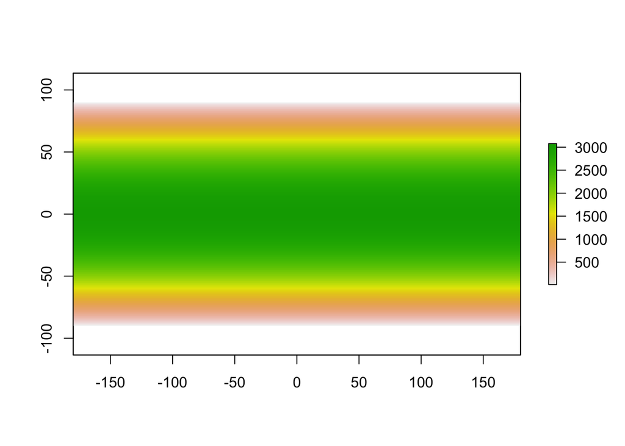

```r
plot(r_a)
```

## Research

### Biodiversity Assessment

- [Zotero | Groups > mbon-indicators > Library](https://www.zotero.org/groups/2202521/mbon-indicators/items)
- Cochrane et al (2016) [What Is Marine Biodiversity? Towards Common Concepts and Their Implications for Assessing Biodiversity Status](https://www.frontiersin.org/articles/10.3389/fmars.2016.00248/full) *Frontiers in Mar Sci*
- Pimm et al (2014) [The biodiversity of species and their rates of extinction, distribution, and protection](http://science.sciencemag.org/content/344/6187/1246752) *Science*

### PostGIS

- [`rpostgis::`](https://github.com/mablab/rpostgis): R Interface to a ‘PostGIS’ Database
  - [`pgWriteRast(conn, name, raster, bit.depth = NULL, blocks = NULL, constraints = T, overwrite = F)`](https://rdrr.io/cran/rpostgis/man/pgWriteRast.html): write raster to PostGIS database table
    - as RasterStack?
  - [`pgGetRast(conn, name, rast = "rast", bands = 1, boundary = NULL)`](https://rdrr.io/cran/rpostgis/man/pgGetRast.html): load raster from PostGIS database
  - [`pgListRast(conn)`](https://rdrr.io/cran/rpostgis/man/pgListGeom.html): list geometries/rasters
  - [`pgGetBoundary(conn, name, geom = "geom", clauses = NULL)`](https://rdrr.io/cran/rpostgis/man/pgGetBoundary.html): retrieve bounding envelope of geometries or rasters
- [PostGIS Manual](http://postgis.net/docs/)
  - [Chapter 5. Raster Data Management, Queries, and Applications](http://postgis.net/docs/using_raster_dataman.html#RT_Creating_Rasters)
  - [Chapter 9. Raster Reference](https://postgis.net/docs/RT_reference.html)
  - [Chapter 10. PostGIS Raster Frequently Asked Questions](https://postgis.net/docs/RT_FAQ.html)
  - [ST_BandPixelType](http://postgis.net/docs/RT_ST_BandPixelType.html)
  - [WKTRasterTutorial01 – PostGIS](https://trac.osgeo.org/postgis/wiki/WKTRasterTutorial01)
    - “use the `st_intersection()` function and `st_intersects()` operator which operates directly on raster and geometries by vectorizing only the necessary part of the raster before doing the intersection and is one of the main feature of PostGIS WKT Raster”
    - [Summarizing the elevation values for each buffer and exporting the table to CSV](https://trac.osgeo.org/postgis/wiki/WKTRasterTutorial01#SummarizingtheelevationvaluesforeachbufferandexportingthetabletoCSV)
    - [Intersecting a raster with a polygon using PostGIS - artefact error - Geographic Information Systems Stack Exchange](https://gis.stackexchange.com/questions/19856/intersecting-a-raster-with-a-polygon-using-postgis-artefact-error)
- [(15) Vector-raster server-side analysis: A PostGIS benchmark](https://www.researchgate.net/publication/236035254_Vector-raster_server-side_analysis_A_PostGIS_benchmark)
- [Postgres / PostGIS - Of Rasters and GeoJSONs | GeoNET](http://www.geonet.ch/postgres-postgis-of-rasters-and-geojsons/)
  - [postgresql - Create an empty tiled raster table in PostGIS - Stack Overflow](https://stackoverflow.com/questions/37910493/create-an-empty-tiled-raster-table-in-postgis)
- https://github.com/CartoDB/CartoDB
- [sverhoeven/cartodb - Docker Hub](https://hub.docker.com/r/sverhoeven/cartodb/)
  - `docker run -d -p 80:80 -h cartodb.localhost sverhoeven/cartodb`
- [Using Mapbox Vector Tiles in CARTO for Maps & Location Apps — CARTO Blog](https://carto.com/blog/using-mvt-in-carto/)
- [PostGIS Raster test - Draw a figure and click on it to see the avg raster value - Jorge Arévalo bl.ocks.org](http://bl.ocks.org/jorgeas80/4c7169c9b6356858f3cc)
- `raster2pgsql`
- [Working with PostGIS | TileMill](https://tilemill-project.github.io/tilemill/docs/guides/postgis-work/)
- `ST_Shift_Longitude` - [Exploring Data Formats and Fields](https://docs.qgis.org/2.18/en/docs/user_manual/managing_data_source/supported_data.html#vector-layers-crossing-180-degrees-longitude)

### OHI Biodiversity: Species

Here’s how the presence of species (binary, from IUCN range map or AquaMaps RES > 0.4) in a given region was assessed for average extinction risk (using IUCN extinction category.)

- Selig et al (2014) [Global Priorities for Marine Biodiversity Conservation](http://journals.plos.org/plosone/article?id=10.1371/journal.pone.0082898) *PLoS ONE*
- [OHI Goals](http://ohi-science.org/goals/#biodiversity)

$$x_{SPP} = \frac{\sum_{k=1}^{M} (\frac{\sum_{i=1}^{N} w_{i}}{N}) * A_{C}}{A_{T}}$$

- $M$ = number of grid cells in the assessment region
- $N$ = number species in a grid cell $c$
- $A$ = total area of a grid cell [$c$] the assessment region [T]
- $w_{i}$ = status weight assigned per threat

assessed species list and maps: IUCN

- [OHI: Species subgoal](https://rawgit.com/OHI-Science/ohiprep/master/globalprep/spp_ico/v2016/spp_data_prep.html)
- [ohiprep/globalprep/spp_ico/v2018 at master · OHI-Science/ohiprep](https://github.com/OHI-Science/ohiprep/tree/master/globalprep/spp_ico/v2018)
- [Goals](http://ohi-science.org/goals/#biodiversity)
- https://rawgit.com/OHI-Science/ohiprep/master/src/dataOrganization_SOP.html
- [ohiprep/spp_am_v_iucn.R at c18fa47888ab28c36229a796d717d3336d4dc012 · OHI-Science/ohiprep](https://github.com/OHI-Science/ohiprep/blob/c18fa47888ab28c36229a796d717d3336d4dc012/globalprep/spp_ico/vAM_IUCN/spp_am_v_iucn.R)